# LEPobuke: Vizuelizacija podataka u programskom okruženju R

## geom_point: oblik tačaka

- Da promenim oblik svim tačkama (postoji “šifrarnik”)

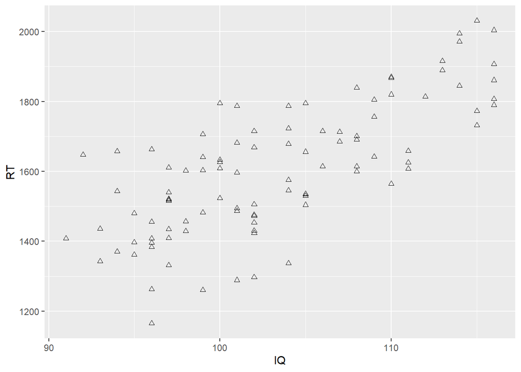

```r
g3 = g0 + geom_point(shape = 24)
g3
```

## geom_point: veličina tačaka

- Da promenimo veličinu svim tačkama

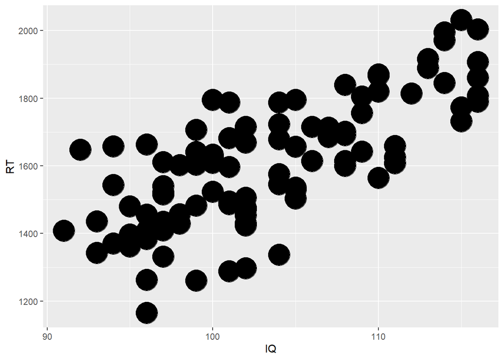

```r
g4 = g0 + geom_point(size = 10)
g4
```

## geom_point: transparentnost tačaka

- Pogodno za big data, za preopterećene grafikone

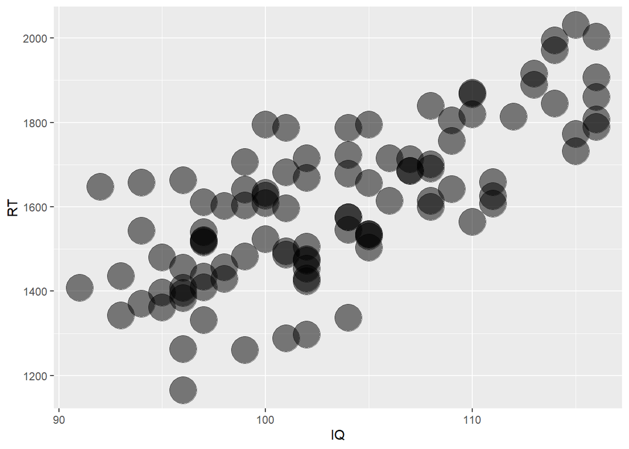

```r
g0 + geom_point(size = 10, alpha = 0.5)
```

## geom_point: da se tačke “razmaknu”

- još jedno rešenje za preopterećene grafikone

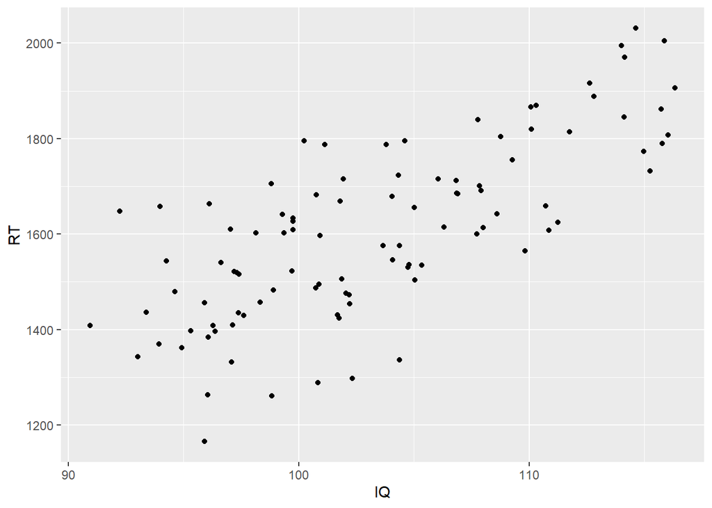

```r
g0 + geom_jitter()
```

## geom_point: da dodamo koeficijent korelacije na grafikon

- prvo pozovemo još jedan paket

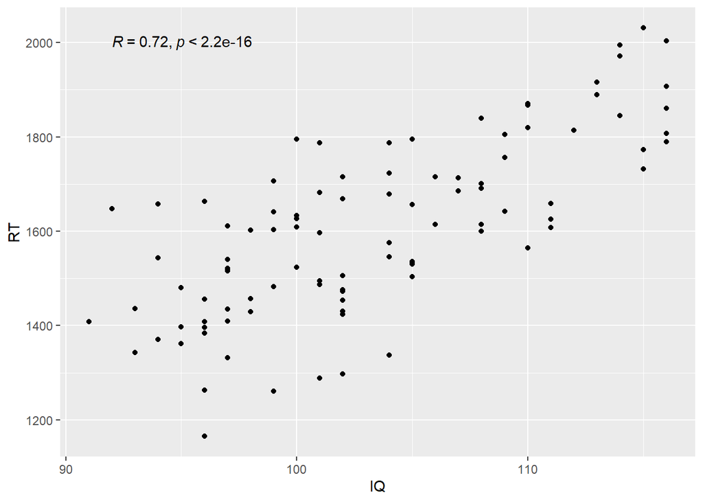

```r
library(ggpubr)
g1 +
  stat_cor(method = "spearman", # odaberemo metod
           label.x = 92, # navedemo koordinatu na x osi na kojoj treba da pocne tekst
           label.y = 2000) # navedemo koordinatu na y osi na kojoj treba da pocne tekst
```

## Regresiona prava

- samo linija

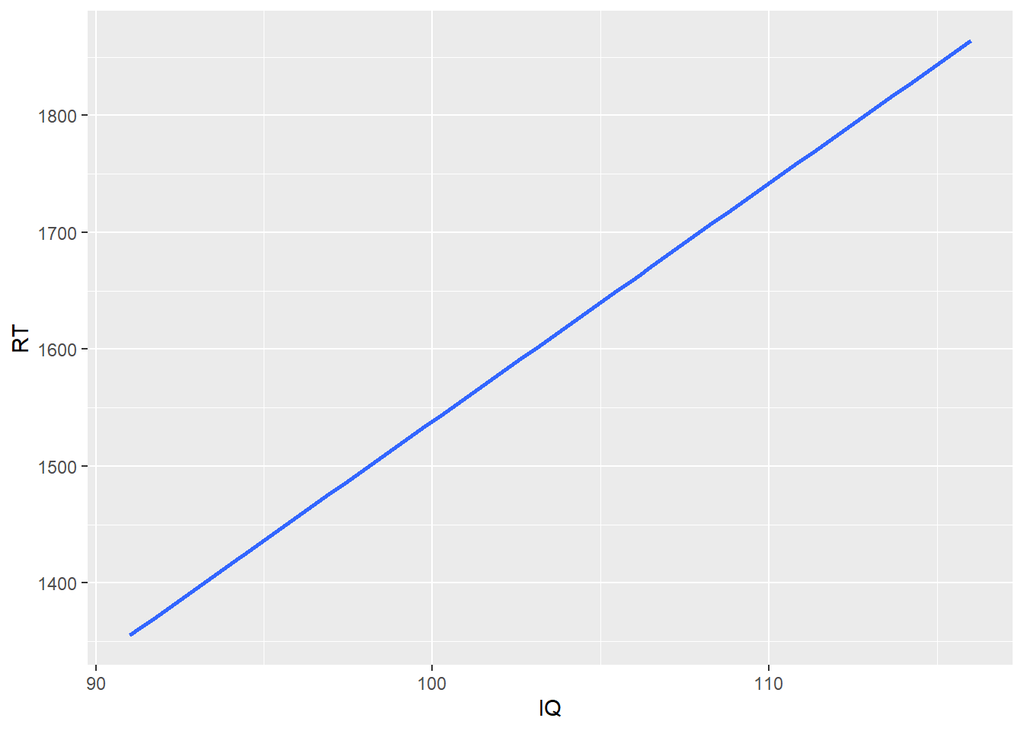

```r
g9 = g0 + geom_smooth(method = "lm", se = FALSE)
g9
```

## Regresiona prava

- linija i 95% CI

```r
g10 = g0 + geom_smooth(method = "lm", se = TRUE)
g10
```

[output not shown]

# Predikcija van opsega zabeleženih vrednosti

- ggplot automatski crta liniju samo unutar zabeleženog raspone
- ako želimo ekstrapolaaciju, moramo to da tražimo:

```r
g0 + geom_smooth(method = "lm", se = TRUE, fullrange=TRUE)
```

[output not shown]

## Regresiona prava

- linija i CI i pojedinačna merenja

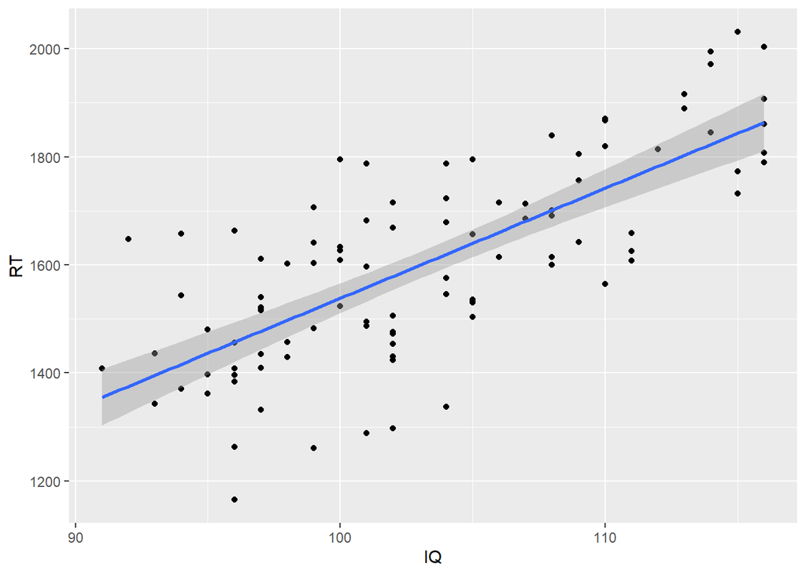

```r
g10 = g1 + geom_smooth(method = "lm", se = TRUE)
g10
```

## Regresiona “kriva”

- za brzi uvid u nelinearnost

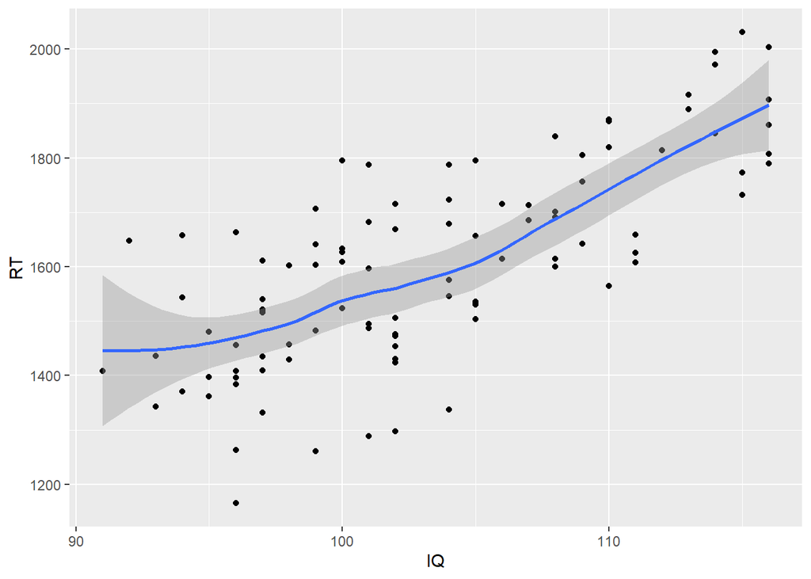

```r
g1 + geom_smooth(method = "loess", se = TRUE)
```

## Regresiona “kriva”

- smanjimo veličinu prozora za računanje lokalnih proseka (dozvolimo veću krivudavost)

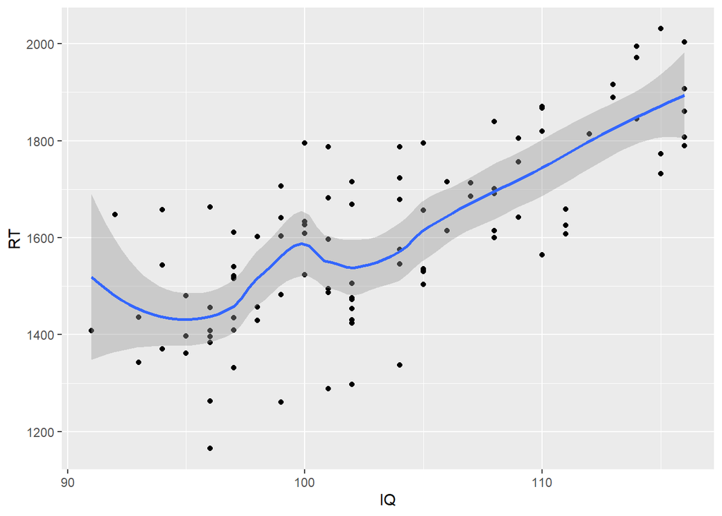

```r
g1 + geom_smooth(method = "loess", se = TRUE, span = 0.5)
```

## Regresiona “kriva”

- dozvolimo još veću krivudavost

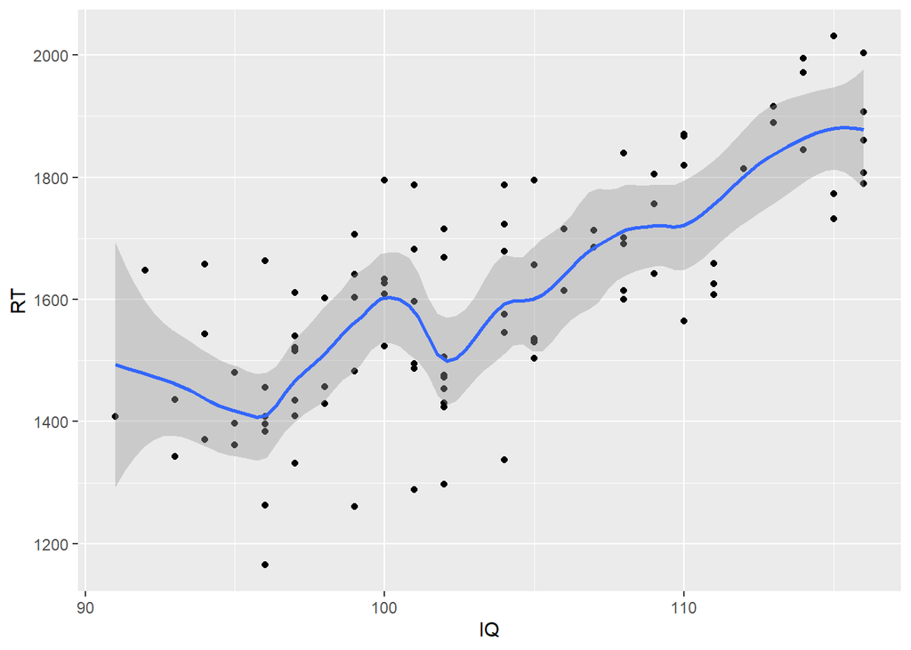

```r
g1 + geom_smooth(method = "loess", se = TRUE, span = 0.3)
```

## Posle prvog upoznavanja sa ggplot2, da se sistematičnije pozabavimo suštinom

- Svaki grafikon ima nekoliko komponenti:
- 1. podatke (najbolje čist i uredan data frame); različiti lejeri mogu da prikazuju različite podatke
- 2. aes: kako se varijable mapiraju na vizuelne karakteristike; mapiranje varijabli na koordinate na osama, boju i veličinu
- 3. geom: naziv geometrijskog objekta koji se koristi za crtanje, način na koji treba prikazati svaku opseravciju (tačke, linije, stubići…)
- 4. stat: vrsta statističke transformacije koju treba primeniti (identity, smooth…)
- 5. position: način na koji se rešava problem preklapanja, kako organizujemo elemente unutar grafikona (jitternig, stacking, dodging), ali i kako organizujemo višestruke grafikone unutar jedne slike (faceting)
- 6. ose: kako ih obeležvamo, orijentišemo i sl.
- 7. koordinatni sistem: mi ćemo se baviti dekartovskim, ali postoje i drugi
- 8. teme: kakav opšti stil dajemo grafikonu (klasični, minimalni…)

## Layer: data

- podaci koje vizualizujemo
- naš data frame
- obično prvi argument funkcije ggplot()

## Layer: aes

- mapiranje varijabli na vizuelne karakteristike
- osnovna: mapiranje varijabli na x i y osu (to smo već videli)

## Layer aes: boja tačaka

- Da stavimo boju tačaka u funkciju neke varijable

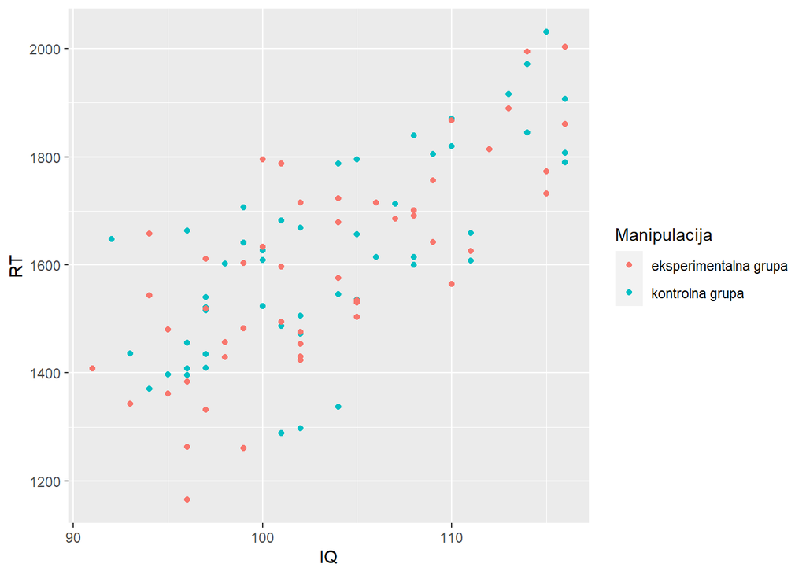

```r
g5 = g1 + aes(colour = Manipulacija)
g5
```

## Layer aes: oblik tačaka

- Da stavimo oblik tačaka u funkciju neke varijable

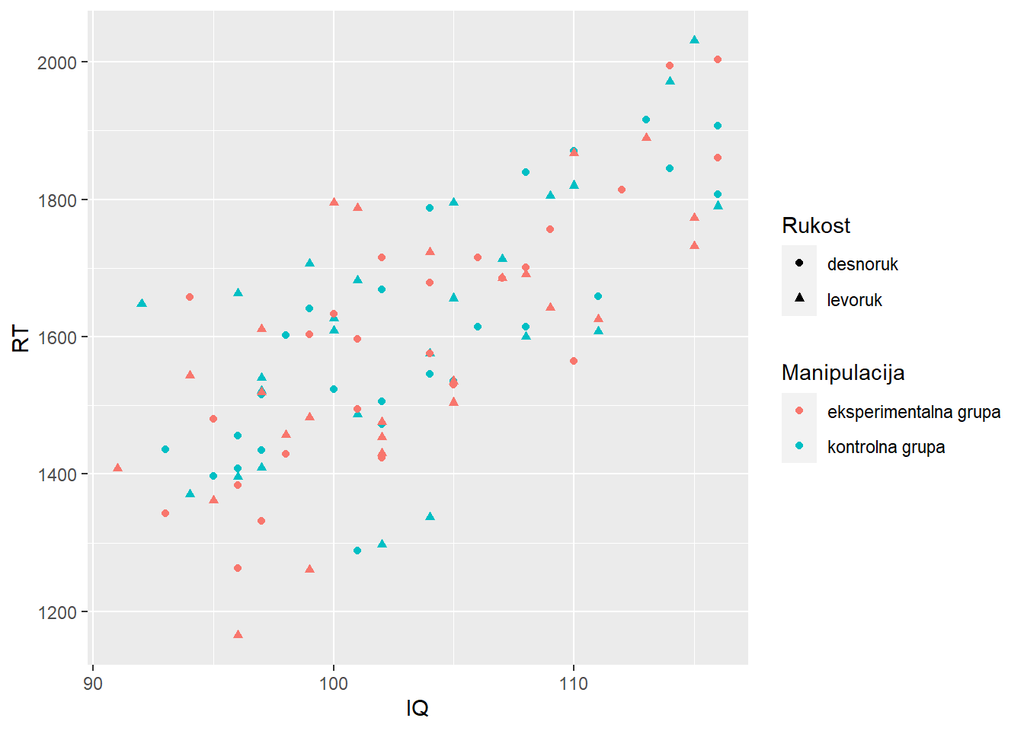

```r
g6 = g5 + aes(shape = Rukost)
g6
```

## Layer aes: veličina tačaka

- Da stavimo veličinu tačaka u funkciju neke varijable

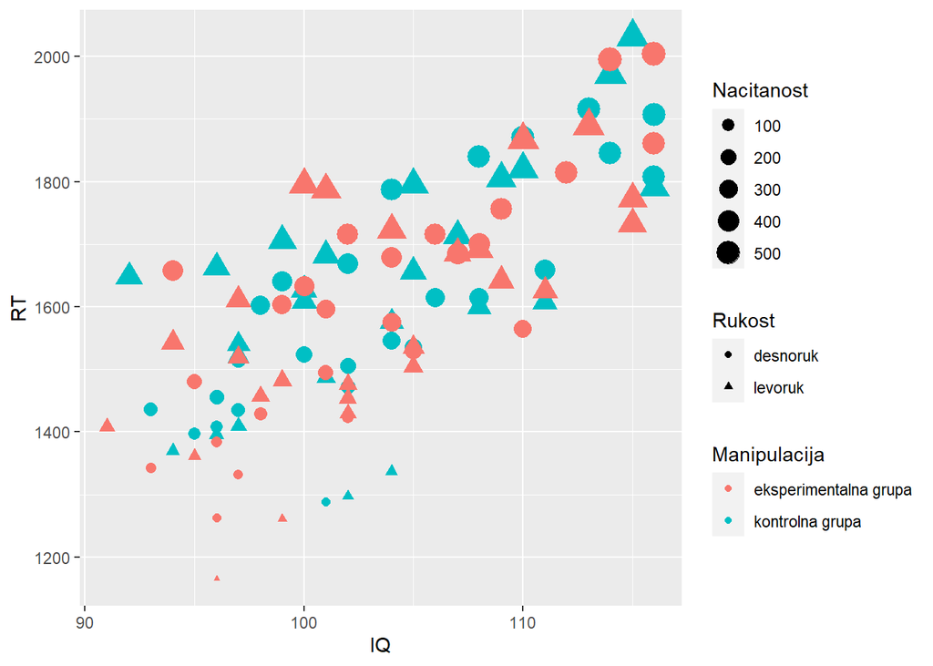

```r
g7 = g6 + aes(size = Nacitanost)
g7
```

## faceting

- podela na “podgrafikone” na osnovu nivoa jedne ili više kategoričkih varijabli

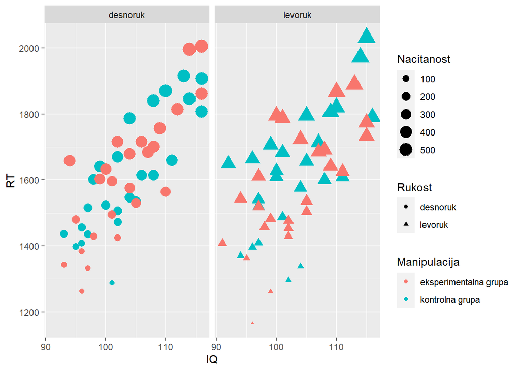

```r
g8 = g7 + facet_wrap(~Rukost)
# za svaki nivo varijable Rukost napravi odvojen grafikon,
# poređa ih u niz i "upakuje" kako je najzgodnije
g8
```

## faceting

- slično, ali nivoi isključivo po kolonama grafikona

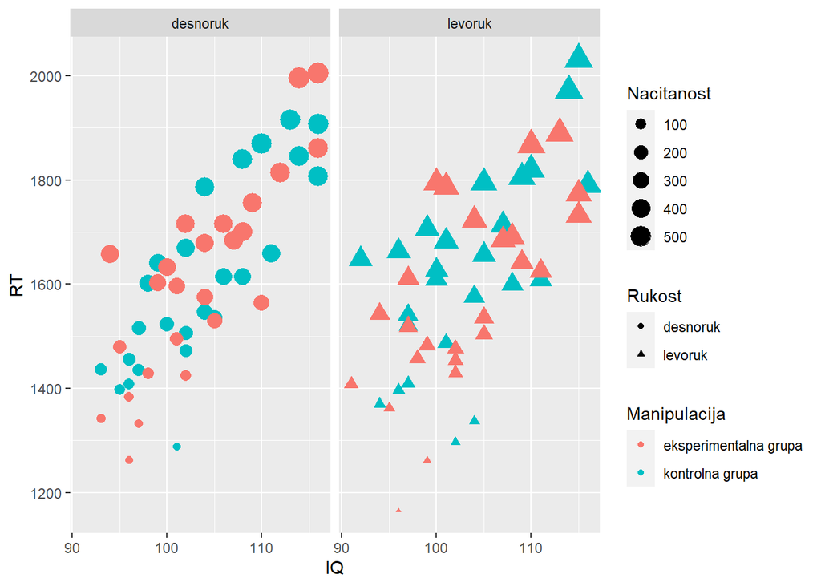

```r
g7 + facet_grid(.~Rukost)
```

## faceting

- slično, ali nivoi isključivo po redovima grafikona

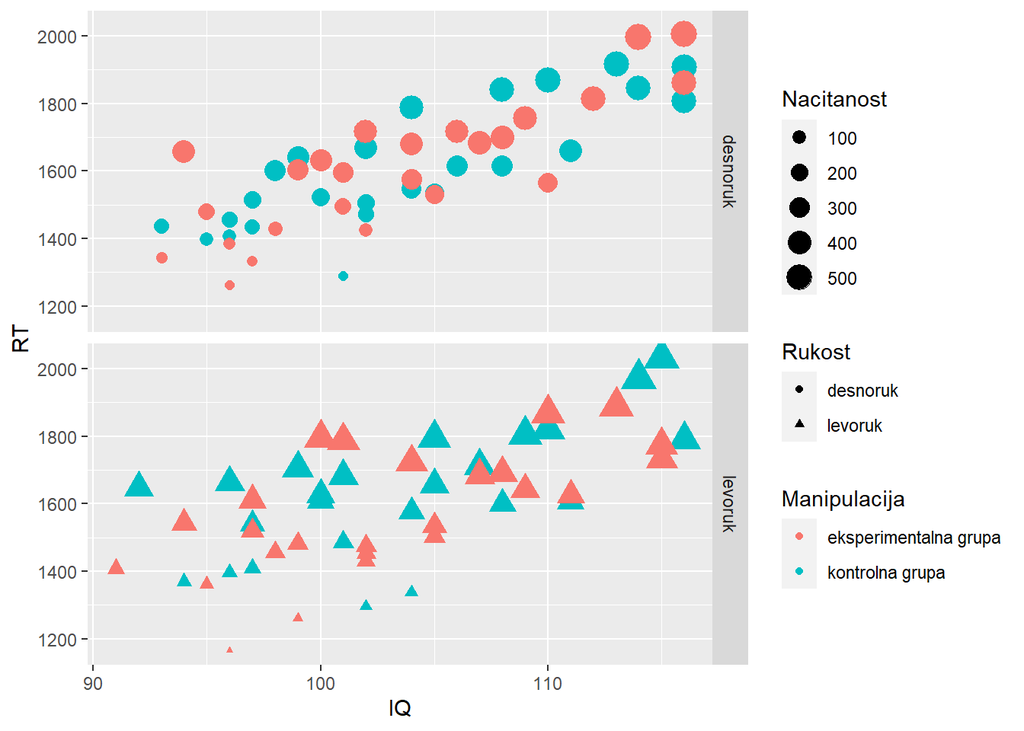

```r
g7 + facet_grid(Rukost~.)
```

## faceting

- da napravimo matricu grafikona:

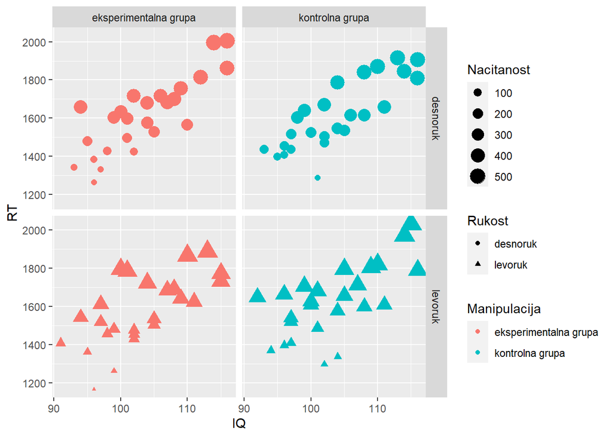

```r
g7 + facet_grid(Rukost~Manipulacija)
```

## Malo mudrosti: upotreba boje u zavisnosti od nivoa na koji se odnosi aes()

- samo tačke različitom bojom, linija zajednička

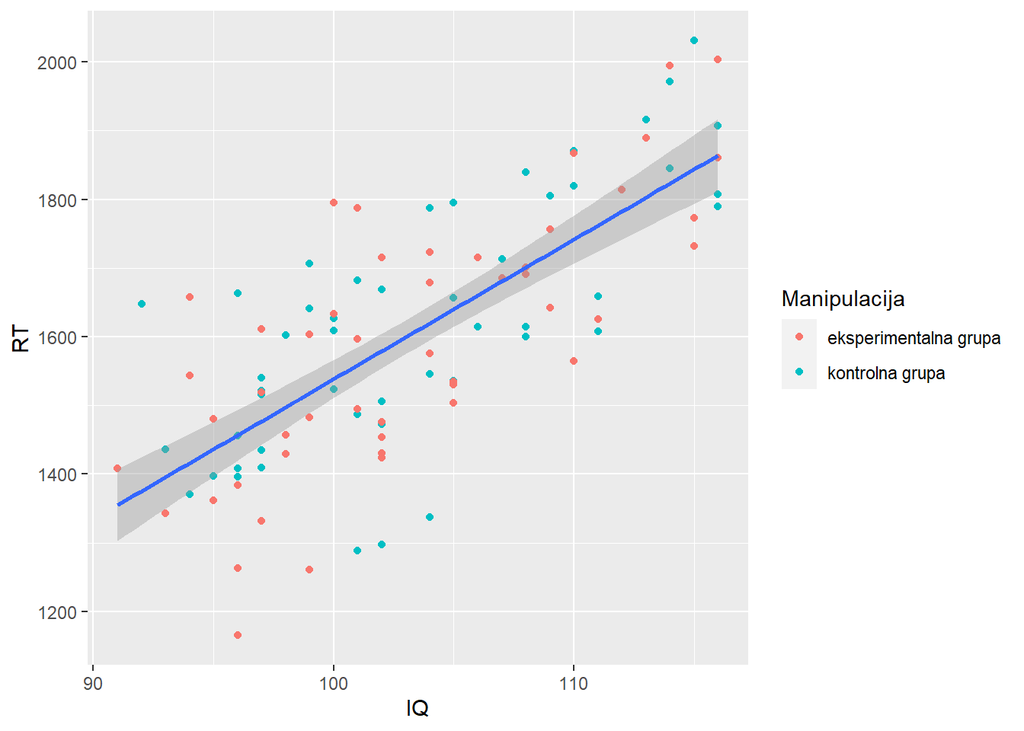

```r
ggplot(dat, aes(x=IQ, y=RT)) +
            geom_point(aes(colour = Manipulacija)) + # dodelimo boju
                                                    # estetici na nivou tačaka
            geom_smooth(method = "lm", se = TRUE)
```

## upotreba boje u zavisnosti od nivoa na koji se odnosi aes()

- tačke različitom bojom i odvojene linije

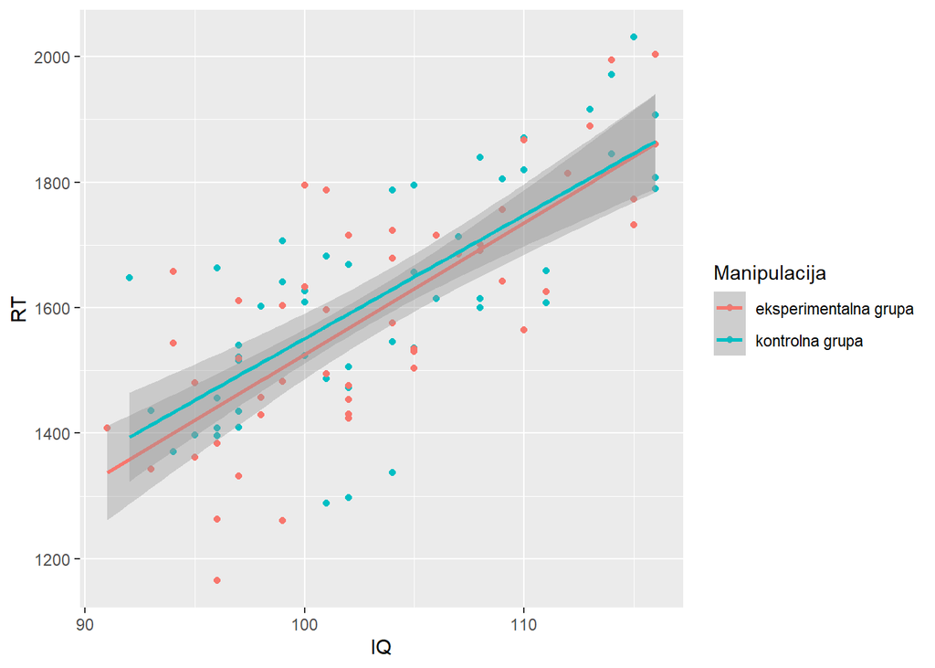

```r
ggplot(dat, aes(x=IQ, y=RT, colour = Manipulacija)) + # dodelimo boju
                                                      # estetici na globalnom nivou
            geom_point() +
            geom_smooth(method = "lm", se = TRUE)
```

## Podešavanje i mapiranje boje: sličan kod, veoma različito značenje

- sada podešavamo boju (dajemo joj sami jednu vrednost)

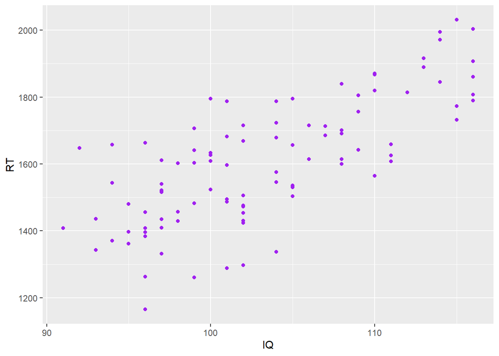

```r
g1+geom_point(colour = "purple")
```

## sada MAPIRAMO boju na vrednost neke varijable (aes se bavi mapiranjem vrednosti varijable na vizuelni domen, ne vizuelnim aspektima samim po sebi)

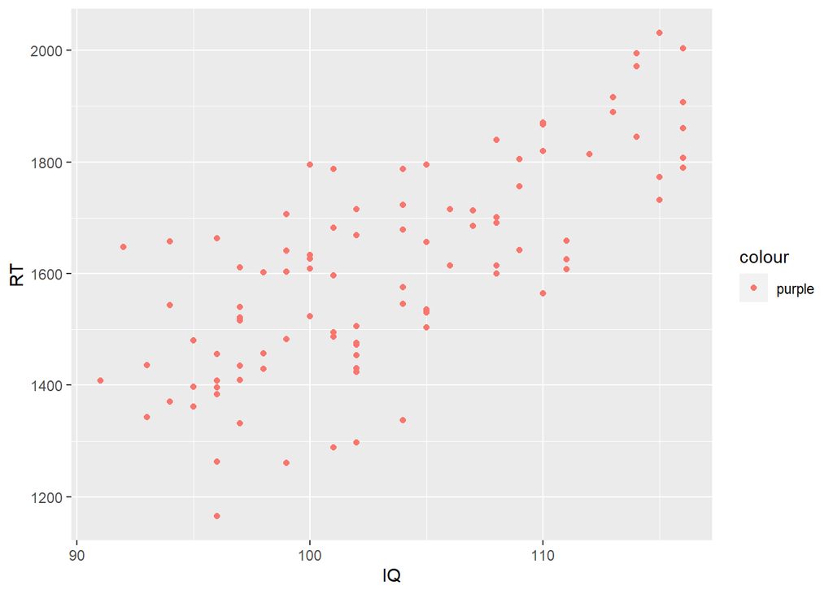

```r
g1+geom_point(aes(colour = "purple")) # pošto ne postoji varijabla koja se zove "purple", R je napravio takvu varijablu, jer smo mu to tražili
```

## Ponekad je zgodno iskoristiti boju da uporedimo regresione linije

- Napravimo sami nivoe nove varijable na koje ćemo mapirati boje

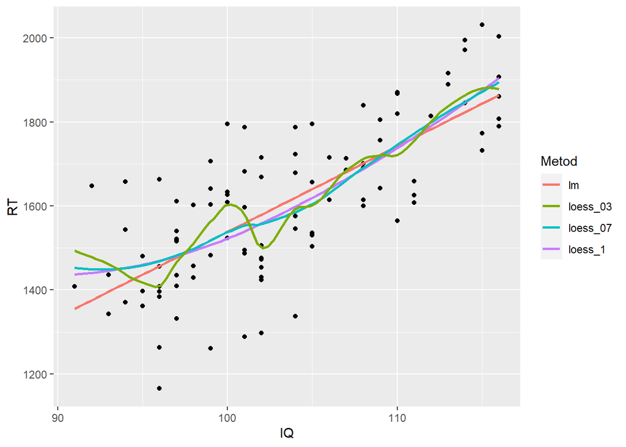

```r
g1 +
  geom_smooth(aes(colour = "lm"), method = "lm", se = FALSE) +
  geom_smooth(aes(colour = "loess_1"), method = "loess", span = 1, se = FALSE) +
  geom_smooth(aes(colour = "loess_07"), method = "loess", span = 0.7, se = FALSE) +
  geom_smooth(aes(colour = "loess_03"), method = "loess", span = 0.3, se = FALSE) +
  labs(colour = "Metod")
```

## Layer: geom

- geometrijski elementi koje koristimo za crtanje
- instrukcije kako da se prikažu vrednosti
- po pravilu: geom_nazivtipaprikaza()

## Layer: geom

- stubići, jedna varijabla

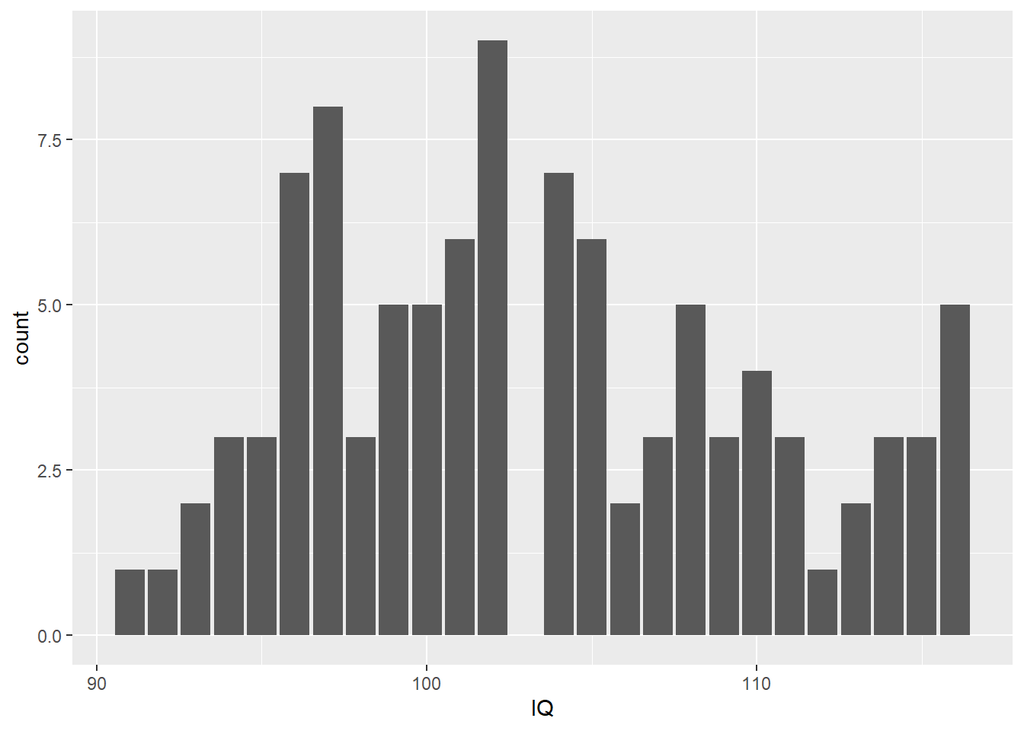

```r
ggplot(dat, aes(x=IQ)) + geom_bar()
```

## Layer: geom

- stubići, dve varijable

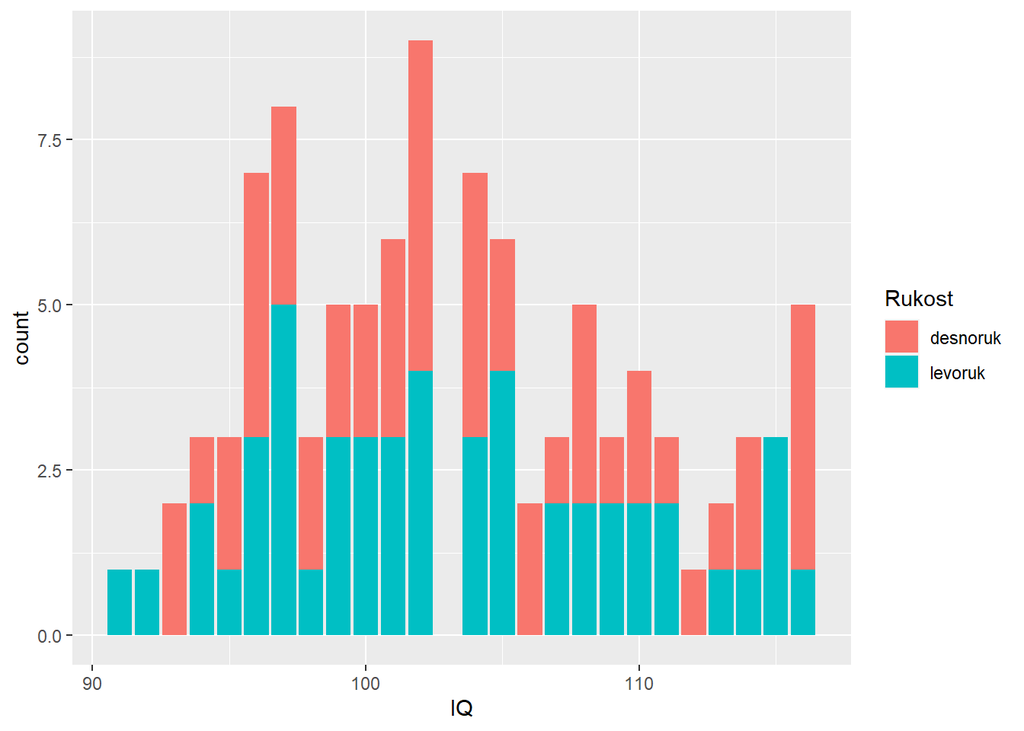

```r
ggplot(dat, aes(x=IQ, fill=Rukost)) + geom_bar()
```

## Layer: geom

- stubići, dve varijable, proporcionalno

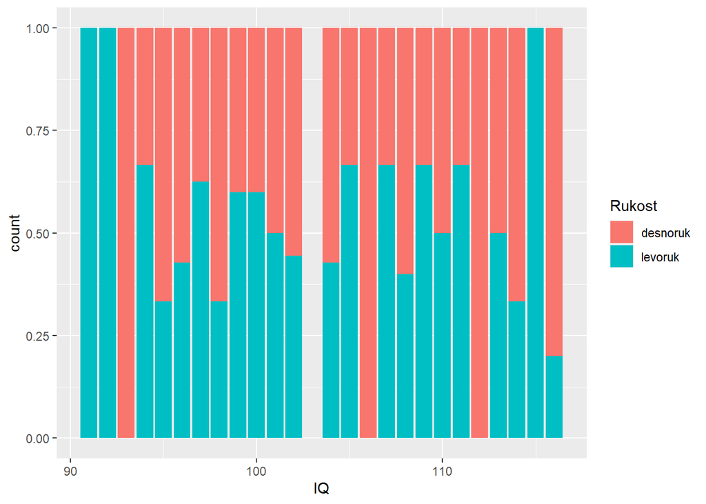

```r
ggplot(dat, aes(x=IQ, fill=Rukost)) + geom_bar(position="fill")
```

## Layer: geom

- histogram, frekvencije

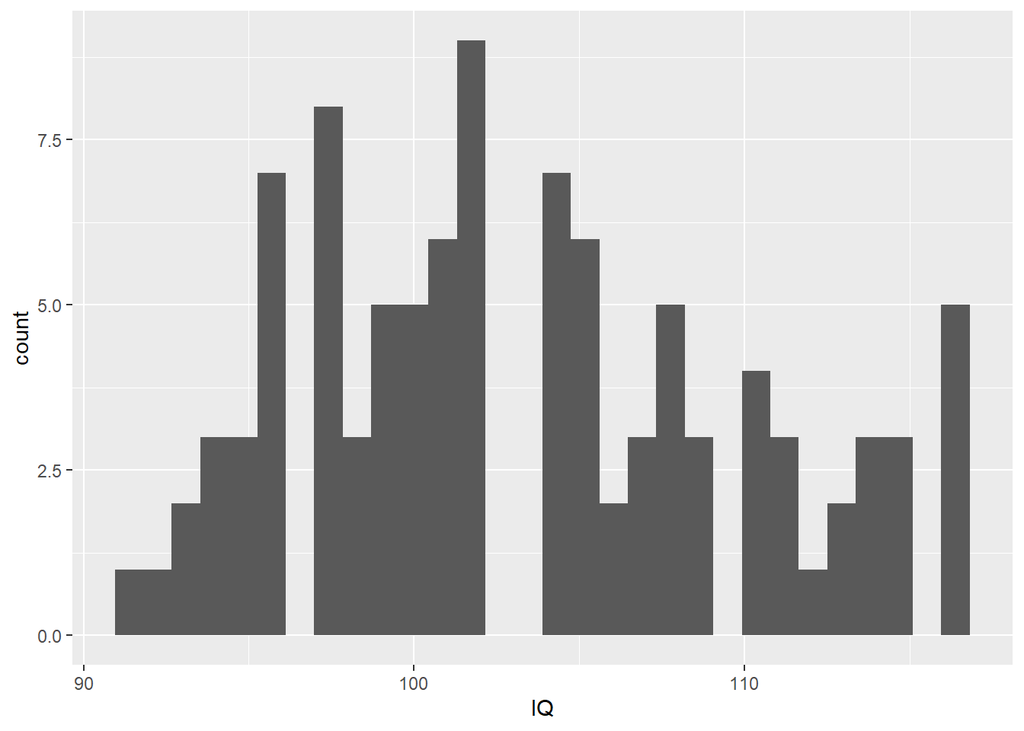

```r
ggplot(dat, aes(IQ)) + geom_histogram()
```

## Layer: geom

- histogram, funkcija gustine verovatnoće

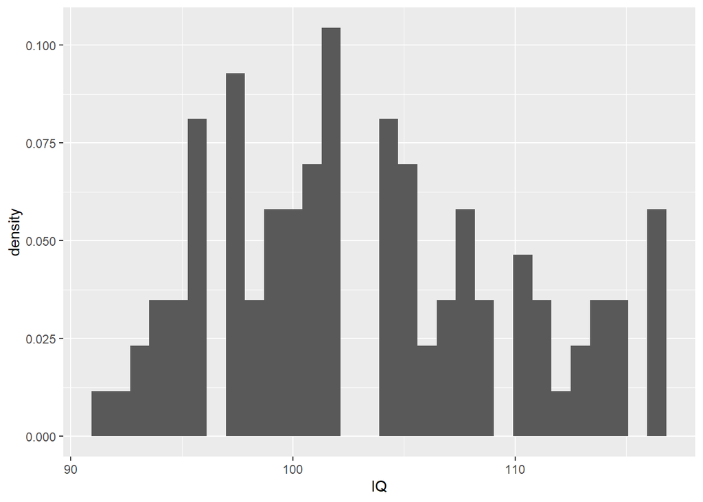

```r
ggplot(dat, aes(IQ)) + geom_histogram(aes(y = ..density..))
```

## Layer: geom

- linija, frekvencije

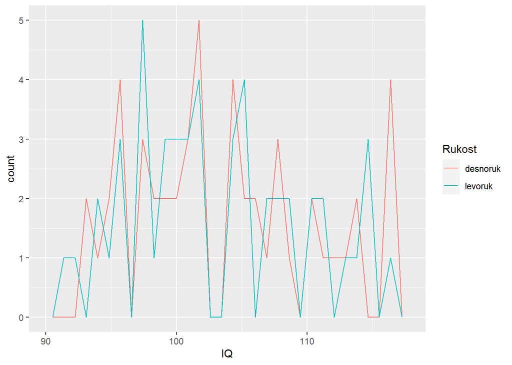

```r
ggplot(dat, aes(IQ, colour = Rukost)) + geom_freqpoly()
```

## Layer: geom

- linija,funkcija gustine verovatnoće

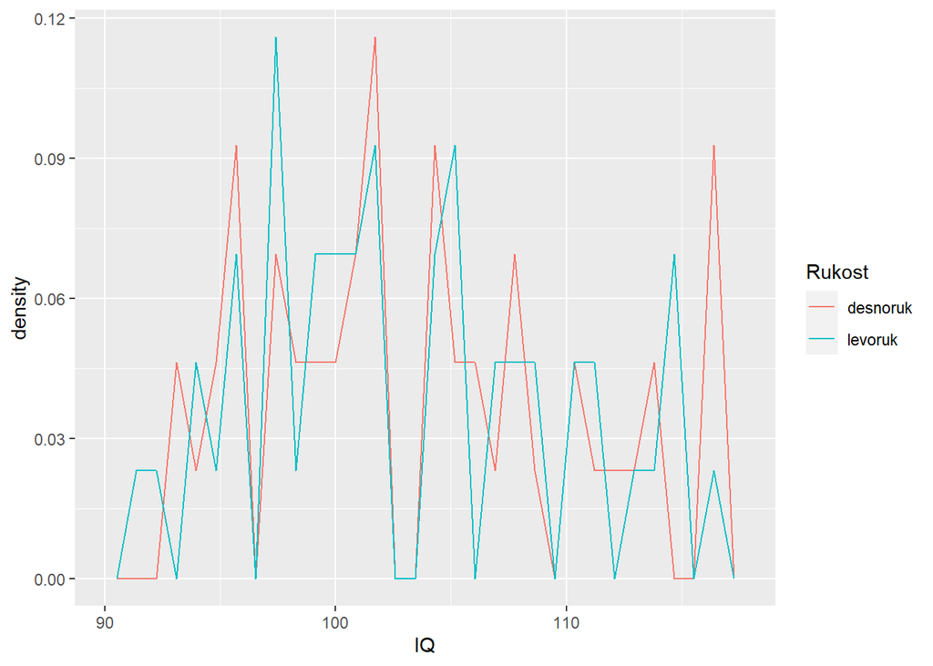

```r
ggplot(dat, aes(IQ, colour = Rukost)) + geom_freqpoly(aes(y = ..density..))
```

## Layer: geom

- funkcije gustine verovatnoće: preklopljene, obojene, delimično transparentne površine

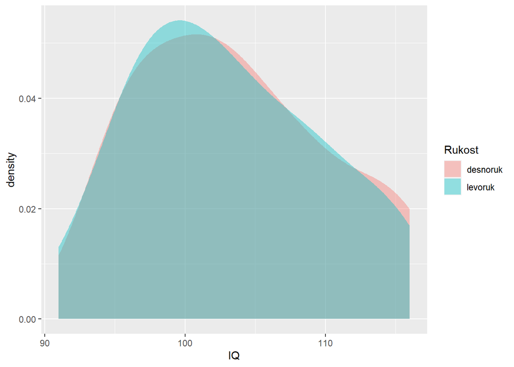

```r
ggplot(dat, aes(IQ, fill = Rukost)) + geom_density(col = NA, alpha = 0.4)
```

## Layer: geom

- 2D funkcija gustine raspodele: topografska mapa

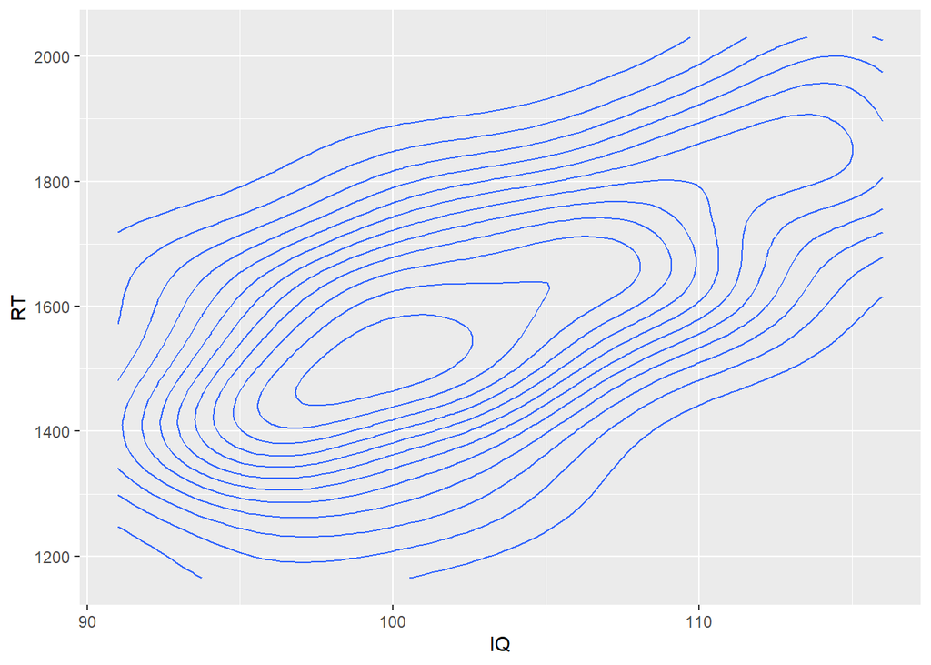

```r
ggplot(dat, aes(x=IQ, y=RT)) + geom_density_2d()
```

## Layer: geom

- 2D funkcija gustine raspodele, boja/senčenje

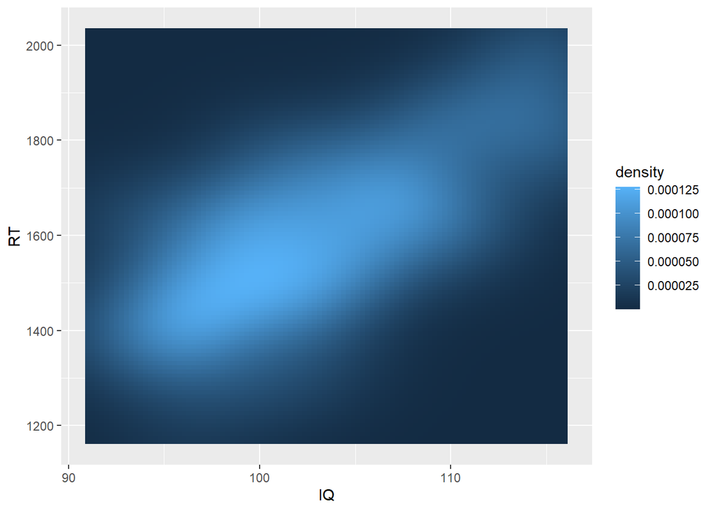

```r
ggplot(dat, aes(x=IQ, y=RT)) + stat_density_2d(geom="tile", aes(fill=..density..), contour=FALSE)
```

## Layer: geom

- box & whiskers

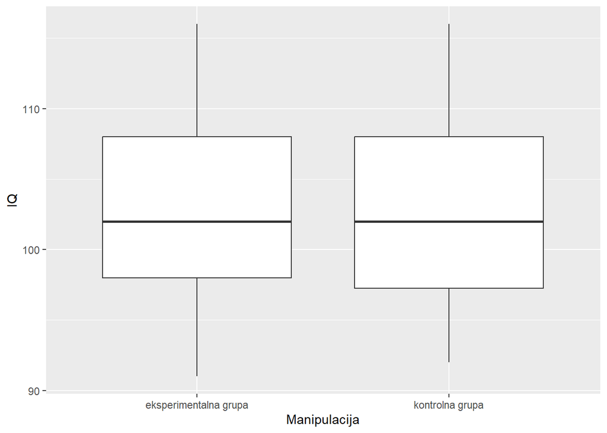

```r
ggplot(dat, aes(x= Manipulacija, y=IQ)) + geom_boxplot()
```

## Layer: geom

- violin

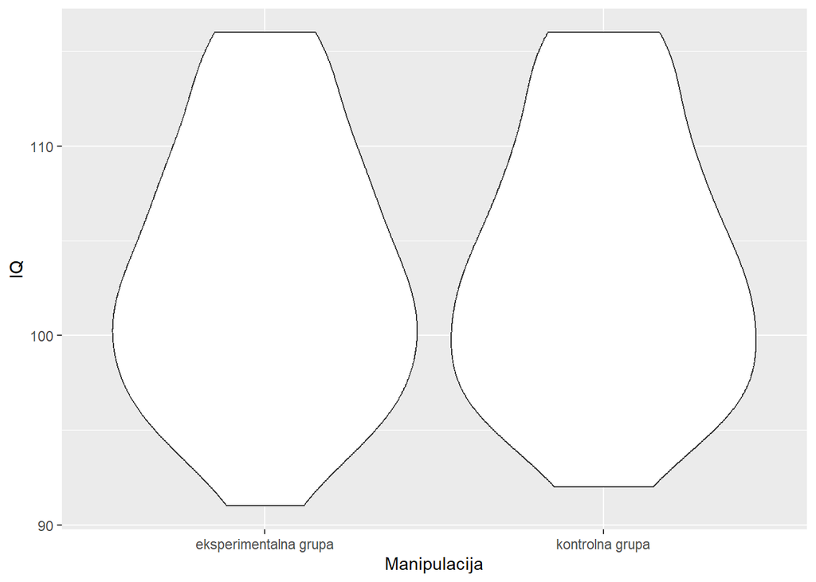

```r
ggplot(dat, aes(x= Manipulacija, y=IQ)) + geom_violin()
```

## Layer: geom

- scatterplot smo već sreli, dodamo rug

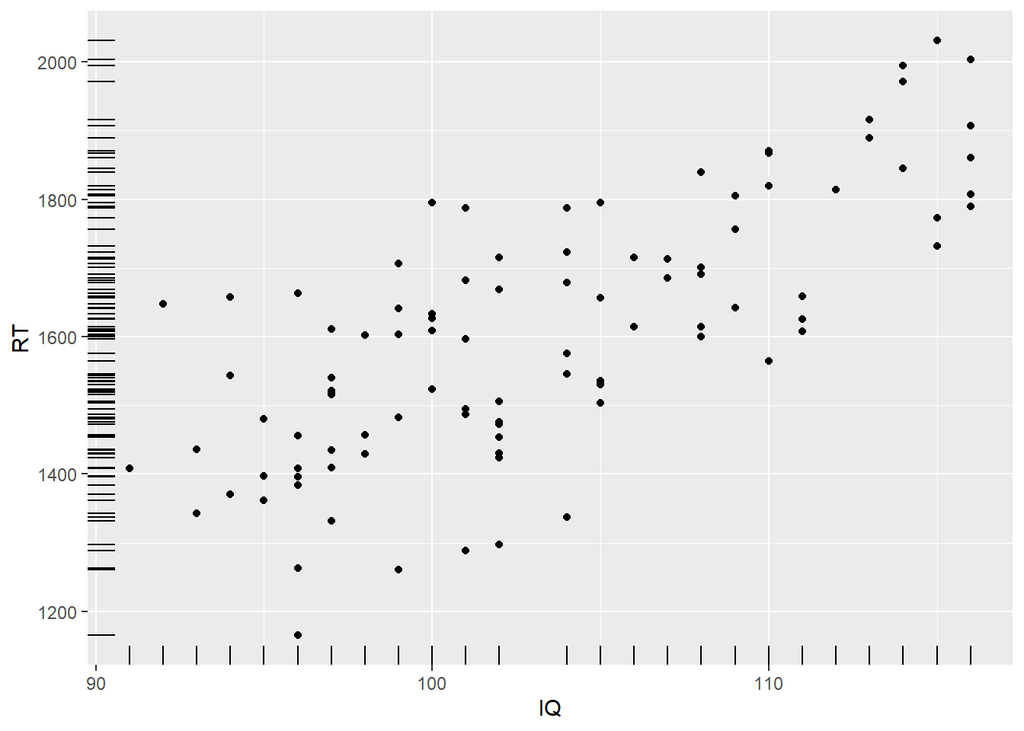

```r
ggplot(dat, aes(x= IQ, y=RT)) + geom_point() + geom_rug()
```

## Layer: geom

- tekst umesto tačaka

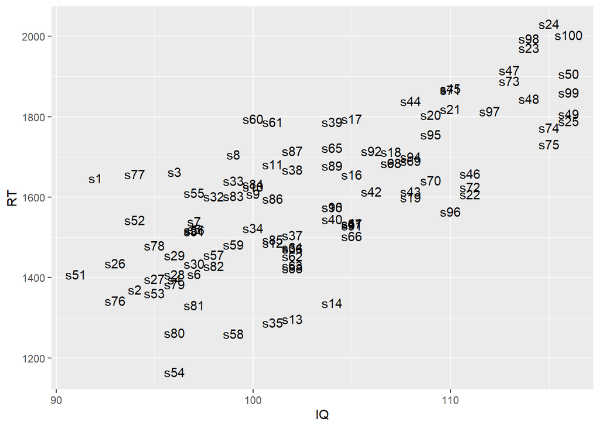

```r
ggplot(dat, aes(x= IQ, y=RT)) + geom_text(aes(label = Ispitanik))
```

## Layer: geom

- isto to…
- malo rasteretimo grafikon

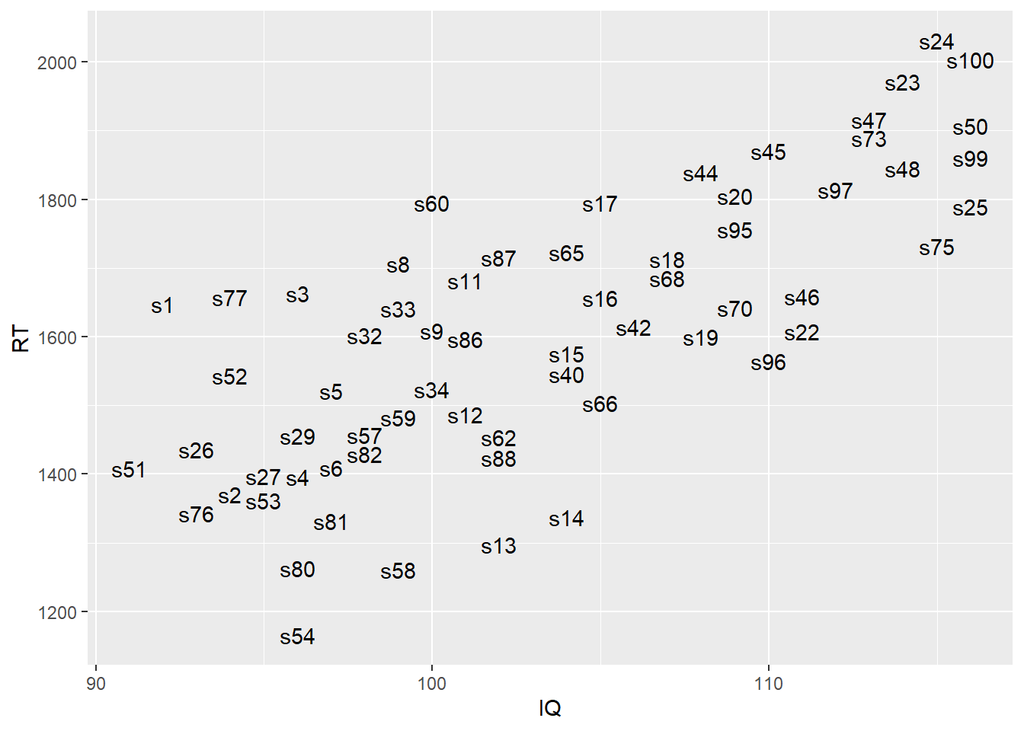

```r
ggplot(dat, aes(x= IQ, y=RT)) + geom_text(aes(label = Ispitanik), check_overlap = TRUE)
```

## Layer: geom

- da se vratimo na tačke i dodamo liniju

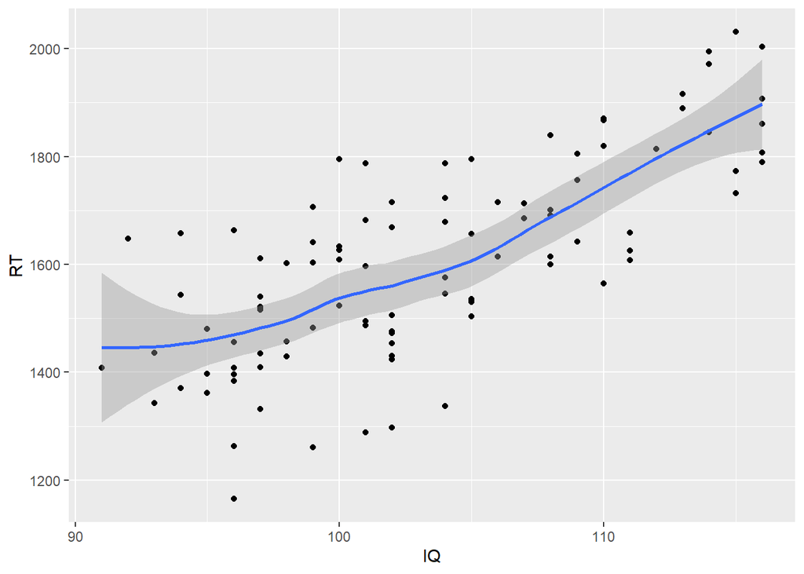

```r
ggplot(dat, aes(x= IQ, y=RT)) + geom_point() + geom_smooth()
```

## Layer: geom

- da dodamo tekst negde, po želji

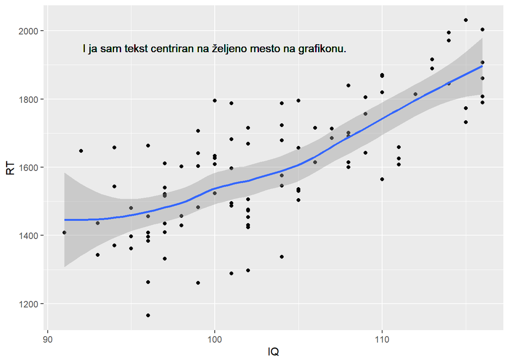

```r
ggplot(dat, aes(x= IQ, y=RT)) + geom_point() + geom_smooth() +
  geom_text(aes(x=100, y=1950,label = "I ja sam tekst centriran na željeno mesto na grafikonu."))
```

## Layer: stat

- svaki stat je u bliskoj vezi sa geom-om, npr. za:
- stat_bin() osnovna operacija je brojanje (geom_bar, geom_histogram)

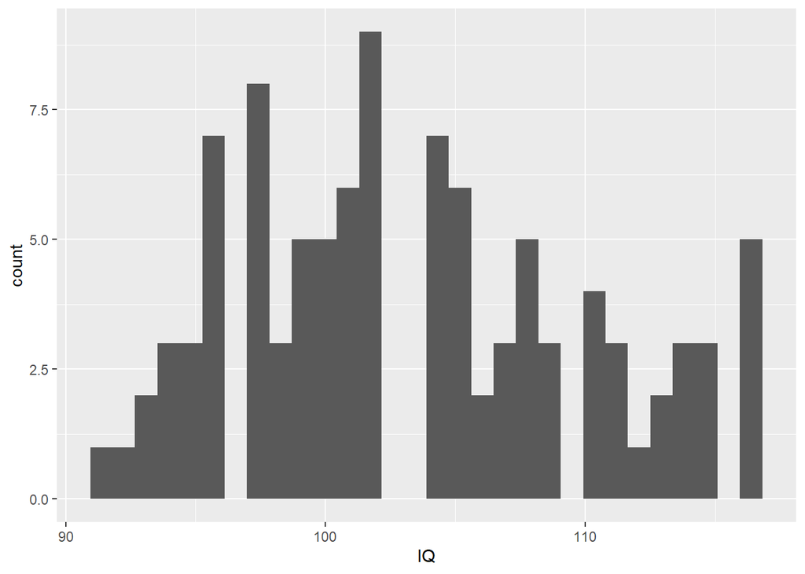

```r
ggplot(dat, aes(IQ)) + stat_bin()
```

```r
# radi isto što i geom_bar() i geom_histogram, jer se ova dva geoma oslanjaju na ovaj stat (brojanje)
```

## Layer: stat

- stat_smooth() osnovna operacija je aproksimiranje grupe tačaka (geom_smooth)

```r
ggplot(dat, aes(IQ,RT)) + stat_smooth(method="lm")
```

[output not shown]

```r
# radi isto što i geom_smooth(method="lm")
```

## Layer: stat

- da prikažemo proseke po kategorijama

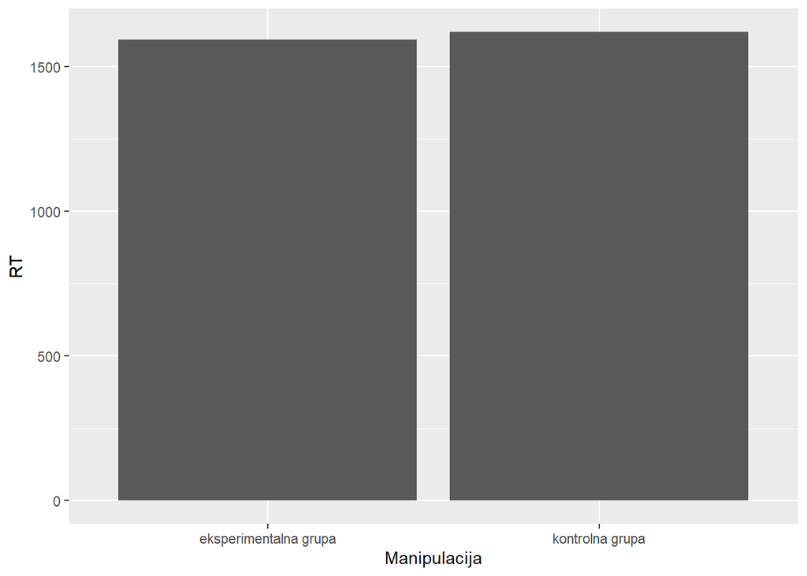

```r
ggplot(dat, aes(x=Manipulacija, y=RT)) +
  stat_summary(fun.y = mean, geom = "bar")
```

## Layer: stat

- da dodamo

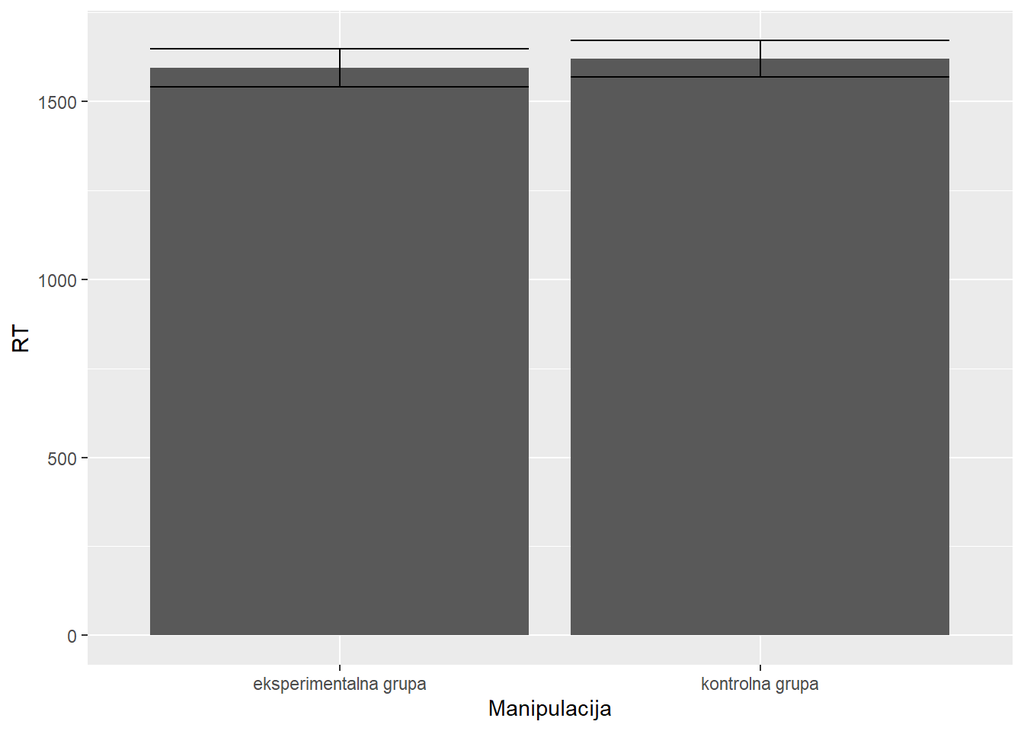

```r
ggplot(dat, aes(x=Manipulacija, y=RT)) +
  stat_summary(fun.y = mean, geom = "bar") +
  stat_summary(fun.data = mean_cl_normal, geom = "errorbar")
```

## Layer: position

- želim da ukrstim Manipulaciju i Rukost
- ništa se ne vidi, jer ggplot automatski ređa stubiće jedan na drugog (position = “stack”)

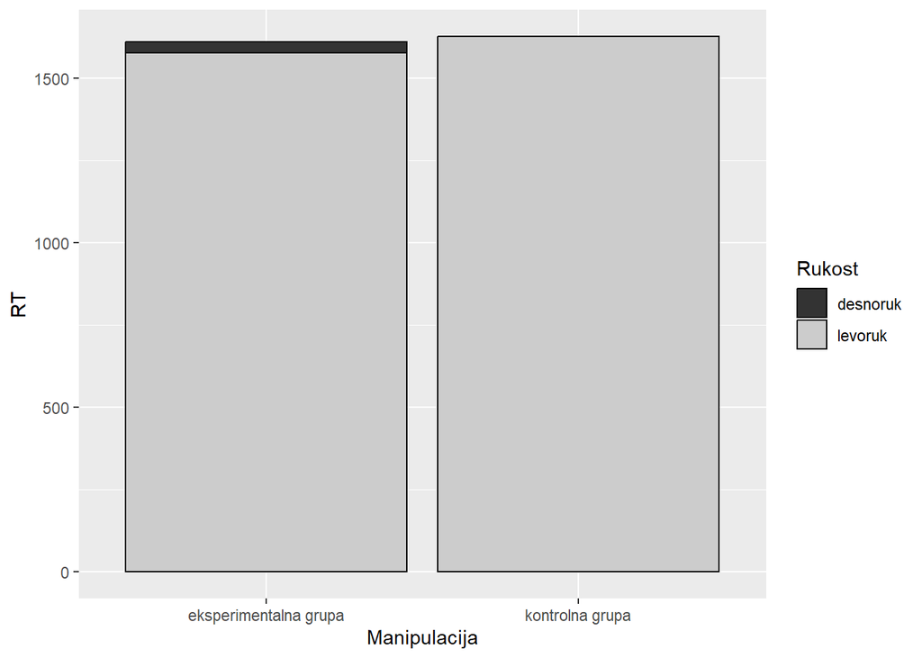

```r
ggplot(dat, aes(x=Manipulacija, y=RT, fill=Rukost)) +
  stat_summary(fun.y = mean, geom = "bar", color="black") +
  scale_fill_grey() # da mi stubići budu u nijansama sive, a ne razbih boja
```

## Layer: position

- da bi se lepo videli, moram da stavim stubiće jedan pored drugog (position = “dodge”)

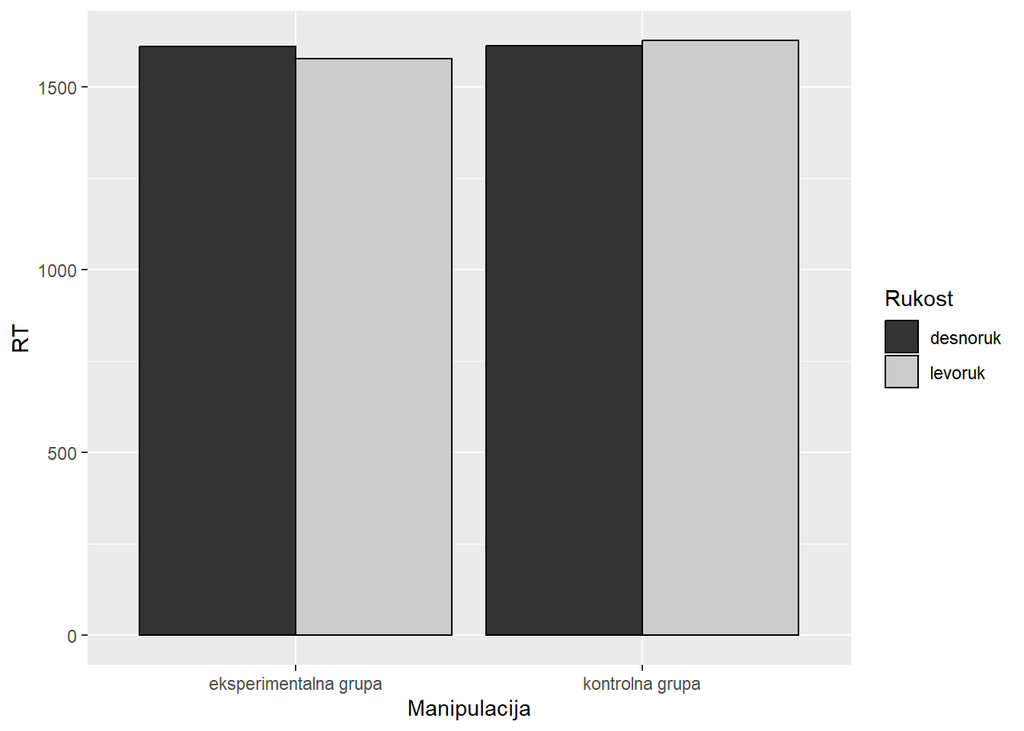

```r
ggplot(dat, aes(x=Manipulacija, y=RT, fill=Rukost)) +
  stat_summary(fun.y = mean, geom = "bar", position = "dodge", color="black") +
  scale_fill_grey()
```

## Layer: position

- ko ne veruje da ih pomeram, da se uveri:

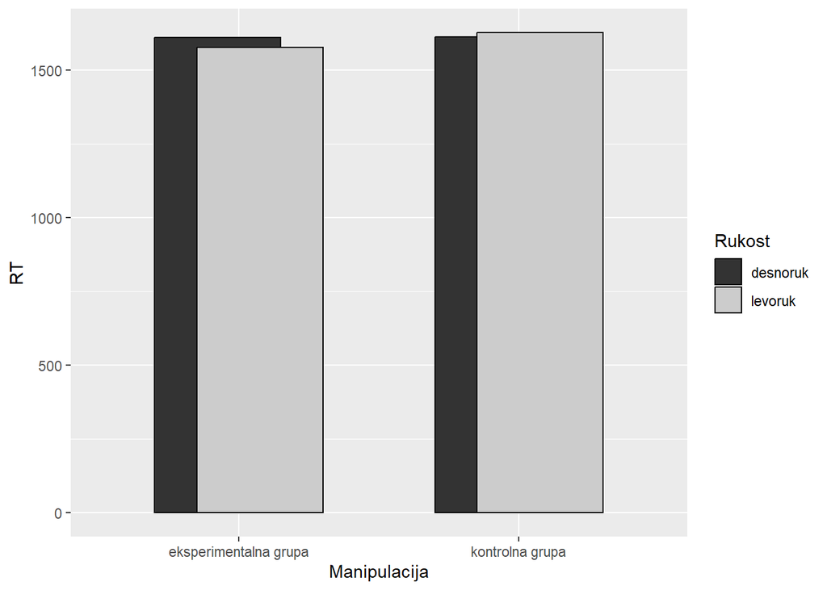

```r
ggplot(dat, aes(x=Manipulacija, y=RT, fill=Rukost)) +
  stat_summary(fun.y = mean, geom = "bar", position = position_dodge(width = 0.30), color="black") +
  scale_fill_grey()
```

## Layer: position

- da promenim širinu stubića

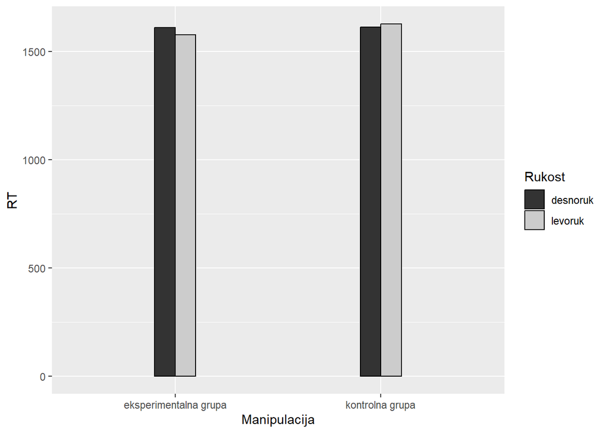

```r
ggplot(dat, aes(x=Manipulacija, y=RT, fill=Rukost)) +
  stat_summary(fun.y = mean, geom = "bar", position = "dodge", width = 0.2, color="black") +
  scale_fill_grey()
```

## Layer: ose

- ovo smo već videli - dajemo naslov grafikonu:

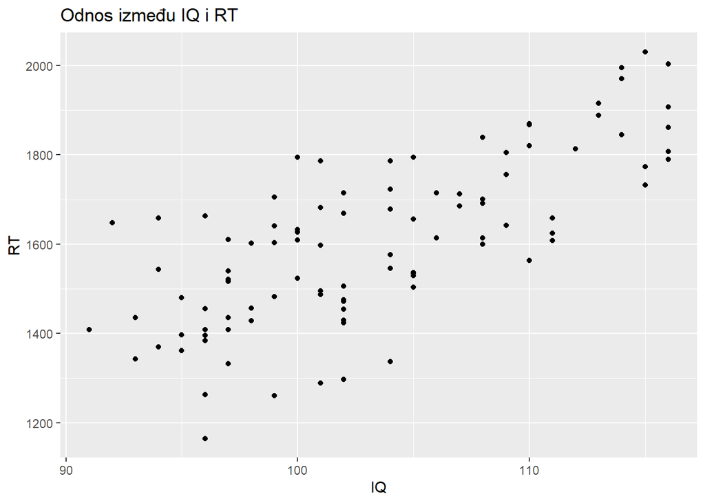

```r
g1 + ggtitle("Odnos između IQ i RT")
```

## Layer: ose

- ovo smo već videli - dajemo nazive osama:

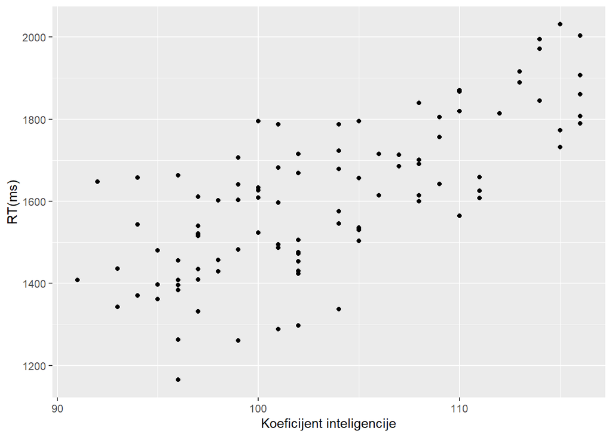

```r
g1 +
  xlab("Koeficijent inteligencije") +
  ylab("RT(ms)")
```

## Layer: ose

- isto to postižemo i sa:

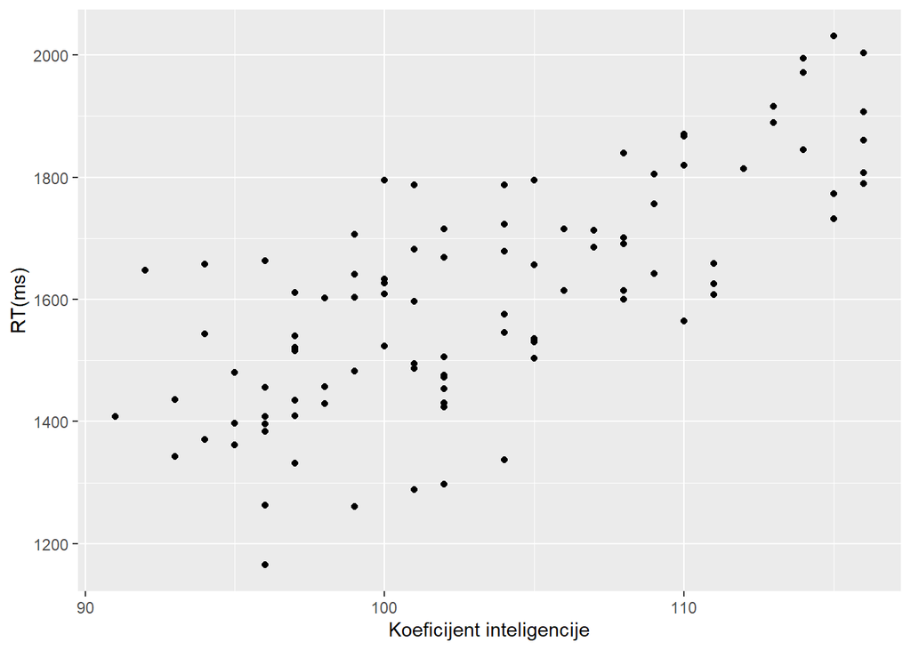

```r
g1 +
  scale_x_continuous("Koeficijent inteligencije") +
  scale_y_continuous("RT(ms)")
```

## Layer: ose

- ako je kategorička varijabla na x osi:

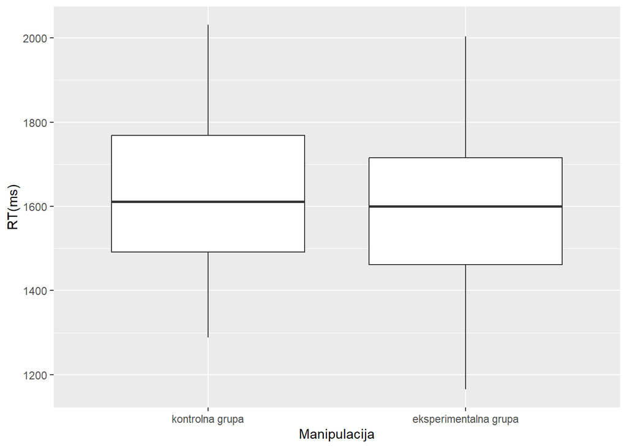

```r
g11 = ggplot(dat, aes(x=Manipulacija, y=RT)) +
  geom_boxplot() +
  scale_x_discrete(limits=c("kontrolna grupa", "eksperimentalna grupa")) +
  # ovo nam dozvoljava da poredjamo nivoe redosledom koji želimo
  scale_y_continuous("RT(ms)")

g11
```

## Layer: ose

- definisanje raspona osa:

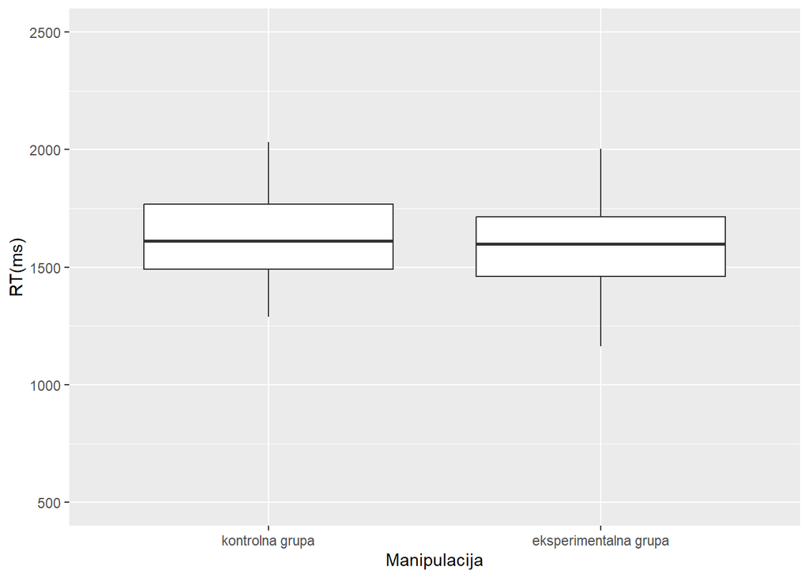

```r
g11 + coord_cartesian(ylim = c(500, 2500))
```

## Layer: ose

- rotiranje grafikona

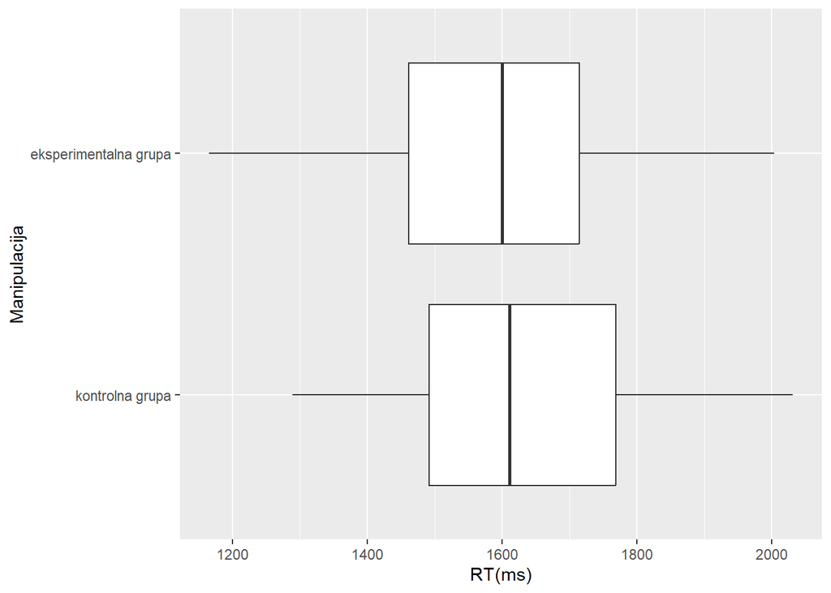

```r
g11 + coord_flip()
```

## koordinatni sistemi

- kod koji pokazuje kako prava i pravougaonik izgledaju u polarnom koordinatnom sistemu
- pozajmljen iz Wickham (2015)

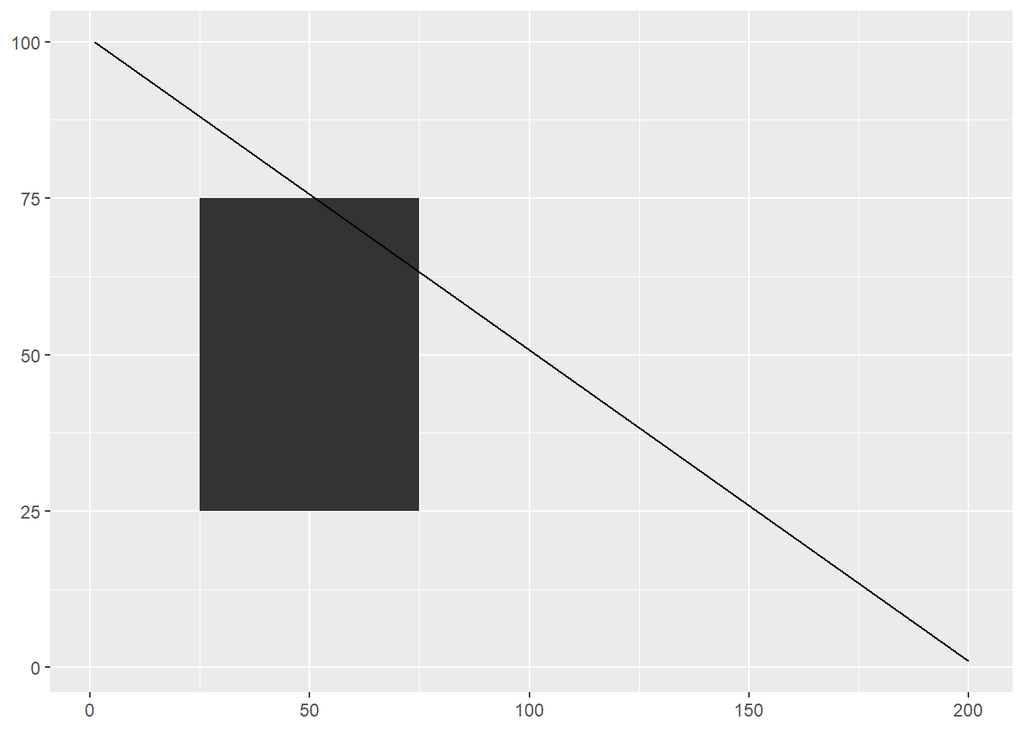

```r
rect <- data.frame(x = 50, y = 50)
line <- data.frame(x = c(1, 200), y = c(100, 1))
base <- ggplot(mapping = aes(x, y)) +
geom_tile(data = rect, aes(width = 50, height = 50)) +
geom_line(data = line) +
xlab(NULL) + ylab(NULL)
base
```

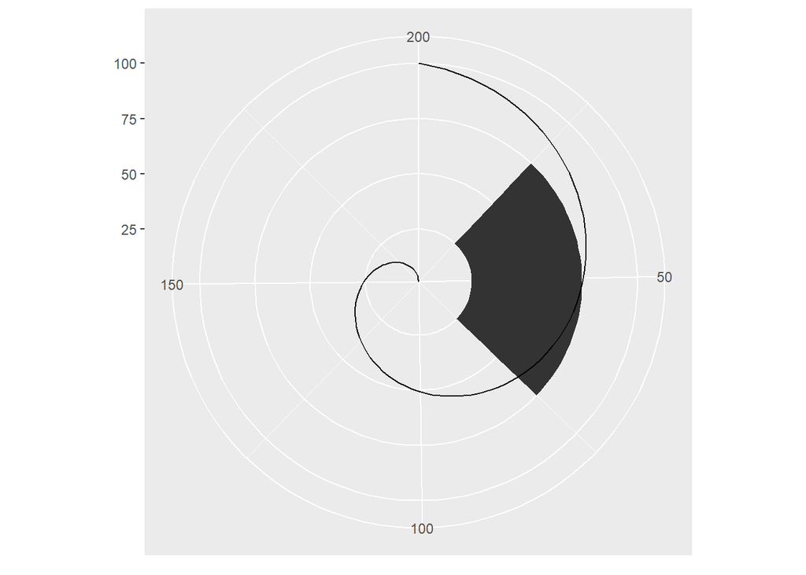

```r
base + coord_polar("x")
```

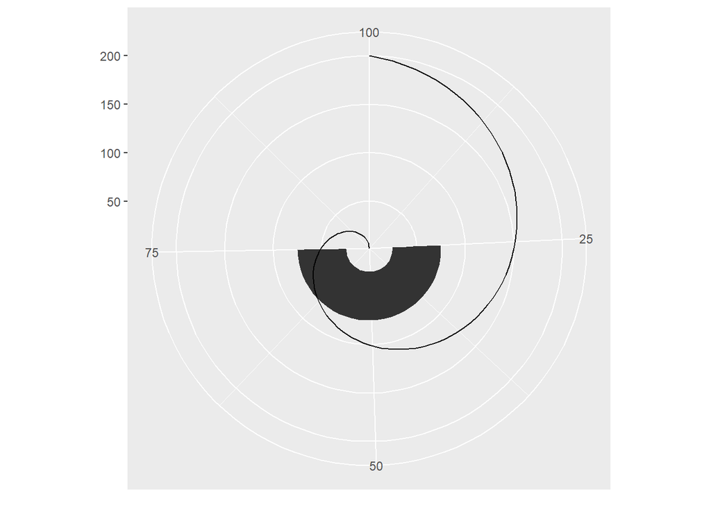

```r
base + coord_polar("y")
```

## Layer: teme

- promenimo temu: bw

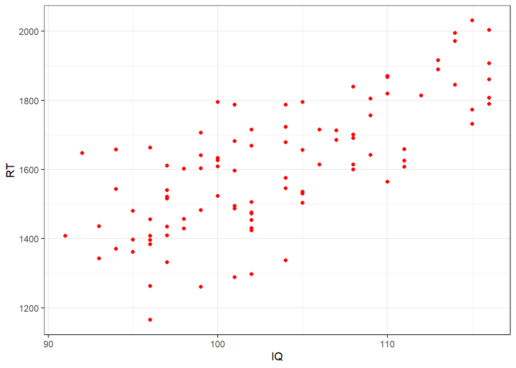

```r
g2 + theme_bw()
```

## Layer: teme

- promenimo temu: classic

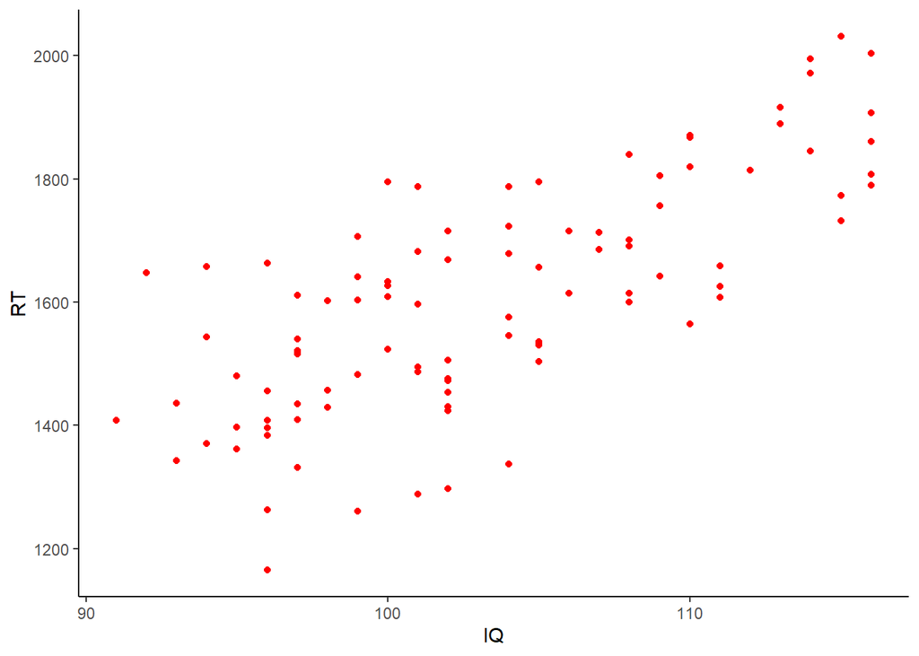

```r
g2 + theme_classic()
```

## Layer: teme

- promenimo temu: minimal
- ima ih još
- pored osnovnih tema, postoji i paket ggthemes sa još većim izborom

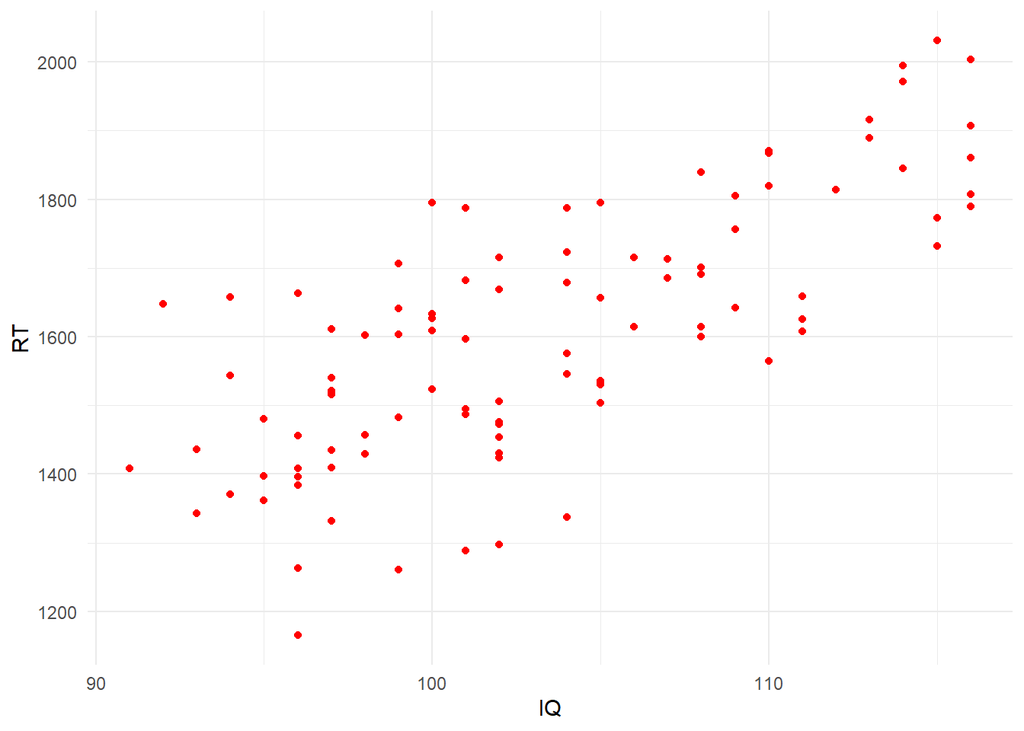

```r
g2 + theme_minimal()
```

## Layer: teme

- kako se sve igramo elementima teme,
- za razgledanje kod kuće:

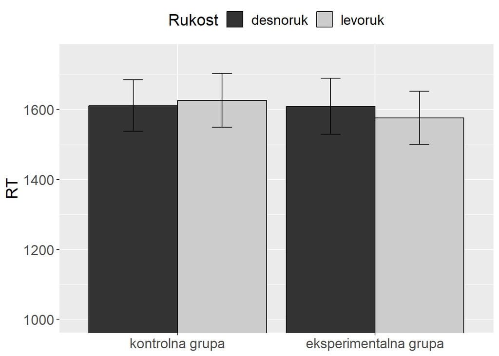

```r
ggplot(data=dat, aes(x=Manipulacija, y=RT, fill=Rukost)) +
  coord_cartesian(ylim = c(1000, 1750)) +
  stat_summary(fun.y = mean, geom = "bar", position = "dodge", color="black") +
   scale_fill_grey() +
   scale_x_discrete(limits=c("kontrolna grupa", "eksperimentalna grupa")) +
   theme(axis.title.y = element_text(size=16), axis.title.x = element_blank()) +
   theme(axis.text.x = element_text(size=14), axis.text.y = element_text(size=14)) +
   theme(legend.title = element_text(size=16)) +
   theme(legend.text = element_text(size=14)) +
   theme(legend.position = "top") +
  stat_summary(fun.data = mean_cl_normal, geom = "errorbar", position = position_dodge(width = 0.90), width = 0.2)
```

## Da sačuvamo grafikon kao sliku:

```r
ggsave("grafikon2.jpeg", width = 5, height = 5)
```

## Da nekoliko grafikona iskombinujemo na jedan panel i sačuvamo kao jednu sliku:

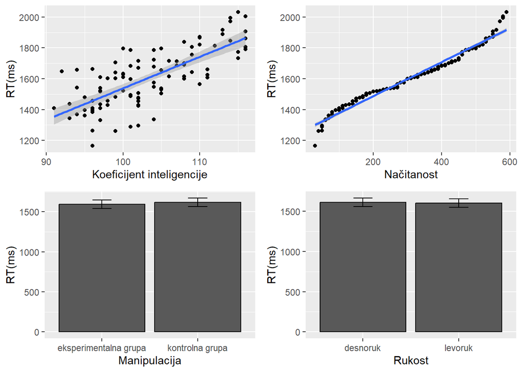

```r
a1 = ggplot(dat, aes(x=IQ, y=RT)) +
  geom_point() +
  xlab("Koeficijent inteligencije") +
  ylab("RT(ms)") +
  geom_smooth(method = "lm", se = TRUE)


a2 = ggplot(dat, aes(x=Nacitanost, y=RT)) +
  geom_point() +
  xlab("Načitanost") +
  ylab("RT(ms)") +
  geom_smooth(method = "lm", se = TRUE)



b1 = ggplot(dat, aes(x=Manipulacija, y=RT)) +
  stat_summary(fun.y = mean, geom = "bar", position = "dodge", color="black") +
  stat_summary(fun.data = mean_cl_normal, geom = "errorbar", position = position_dodge(width = 0.90), width = 0.2) +
  xlab("Manipulacija") +
  ylab("RT(ms)")

b2 = ggplot(dat, aes(x=Rukost, y=RT)) +
  stat_summary(fun.y = mean, geom = "bar", position = "dodge", color="black") +
  stat_summary(fun.data = mean_cl_normal, geom = "errorbar", position = position_dodge(width = 0.90), width = 0.2) +
  xlab("Rukost") +
  ylab("RT(ms)")


library(gridExtra)

Moj_panel = grid.arrange(a1, a2, b1, b2, nrow = 2)
```

```r
ggsave("Panel_grafikona.jpeg", Moj_panel, width = 10, height = 10)
```

## Postoji još mnogo mogućnosti

- Razne transformacije podataka
- Dodavanje teksta na željenu lokaciju na grafikonu
- Promena rasporeda elemenata grafikona
- Animirani i interaktivni grafikoni!
- Čak i programiranje u ggplot!

## Za sve što ne znate napamet (tj. za većinu stvari):

- guglajte frazu koja opisuje to što želite da izvedete (obilje blogova)
- https://raw.githubusercontent.com/rstudio/cheatsheets/main/data-visualization.pdf